# Processing, analyzing, and interpreting epigenome-wide DNA methylation data

Andrea Baccarelli, Andres Cardena, Elena Colicino, Jonathan Heiss, Allan Just

June, 2018

Local library

```r
.libPaths("C:/EBC3/Rpackages")
```

# Processing methylation data

Load packages that we will use focusing on *minfi*:  
see [Aryee et al. Bioinformatics 2014](http://doi.org/10.1093/bioinformatics/btu049). Other popular options for processing & analyzing methylation data include RnBeads and methylumi

```r
suppressMessages(library(minfi)) # popular package for methylation data
library(shinyMethyl) # for visualizing quality control
library(pryr) # for monitoring memory use
suppressMessages(library(matrixStats)) # for calculating summary statistics
library(ENmix) # probe type adjustment "rcp"
```

```r
suppressMessages(library(limma)) # for MDS plots
suppressMessages(library(reshape,scales)) # reshape data and graphig
suppressMessages(require(sva)) # for addressing batch effects
library(IlluminaHumanMethylationEPICmanifest) # manifest for Illumina's EPIC methylation
library(IlluminaHumanMethylationEPICanno.ilm10b2.hg19) # annotation for Illumina's EPIC methylation arrays.
```

Here we will use an existing methylation dataset - EPIC in peripheral blood (20 samples)  
To read in your own dataset (usually “idat files” ending in .idat)  
See the help for ?read.metharray.exp

```r
#library(EPICdemo) # example dataset - not a publically available package
```

import EPIC data from a sample sheet and idat files

```r
idatPath <- "C:/EBC3/idat" # path of the folder
targets <- read.csv("C:/EBC3/idat/sample.info.csv", strip.white=T, stringsAsFactors=F) #sample information
targets$Basename <- paste0(targets$Sentrix_ID, "_", targets$Sentrix_Position) # name of the files
WB <- read.metharray.exp(base=idatPath, targets=targets, verbose=T) # read the idat file one by one
```

```
## [read.metharray] Reading 200383290092_R01C01_Grn.idat
```

```
## [read.metharray] Reading 200379150024_R04C01_Grn.idat
```

```
## [read.metharray] Reading 200379150024_R05C01_Grn.idat
```

```
## [read.metharray] Reading 200379150024_R08C01_Grn.idat
```

```
## [read.metharray] Reading 200383290066_R02C01_Grn.idat
```

```
## [read.metharray] Reading 200383290112_R03C01_Grn.idat
```

```
## [read.metharray] Reading 200383880005_R06C01_Grn.idat
```

```
## [read.metharray] Reading 200383880020_R05C01_Grn.idat
```

```
## [read.metharray] Reading 200383880077_R02C01_Grn.idat
```

```
## [read.metharray] Reading 200383880080_R02C01_Grn.idat
```

```
## [read.metharray] Reading 200383290112_R01C01_Grn.idat
```

```
## [read.metharray] Reading 200383880080_R07C01_Grn.idat
```

```
## [read.metharray] Reading 200383290110_R05C01_Grn.idat
```

```
## [read.metharray] Reading 200383880006_R06C01_Grn.idat
```

```
## [read.metharray] Reading 200383880006_R08C01_Grn.idat
```

```
## [read.metharray] Reading 200383290092_R03C01_Grn.idat
```

```
## [read.metharray] Reading 200379150024_R03C01_Grn.idat
```

```
## [read.metharray] Reading 200379150024_R07C01_Grn.idat
```

```
## [read.metharray] Reading 200383290066_R04C01_Grn.idat
```

```
## [read.metharray] Reading 200383290066_R05C01_Grn.idat
```

```
## [read.metharray] Reading 200383290092_R01C01_Red.idat
```

```
## [read.metharray] Reading 200379150024_R04C01_Red.idat
```

```
## [read.metharray] Reading 200379150024_R05C01_Red.idat
```

```
## [read.metharray] Reading 200379150024_R08C01_Red.idat
```

```
## [read.metharray] Reading 200383290066_R02C01_Red.idat
```

```
## [read.metharray] Reading 200383290112_R03C01_Red.idat
```

```
## [read.metharray] Reading 200383880005_R06C01_Red.idat
```

```
## [read.metharray] Reading 200383880020_R05C01_Red.idat
```

```
## [read.metharray] Reading 200383880077_R02C01_Red.idat
```

```
## [read.metharray] Reading 200383880080_R02C01_Red.idat
```

```
## [read.metharray] Reading 200383290112_R01C01_Red.idat
```

```
## [read.metharray] Reading 200383880080_R07C01_Red.idat
```

```
## [read.metharray] Reading 200383290110_R05C01_Red.idat
```

```
## [read.metharray] Reading 200383880006_R06C01_Red.idat
```

```
## [read.metharray] Reading 200383880006_R08C01_Red.idat
```

```
## [read.metharray] Reading 200383290092_R03C01_Red.idat
```

```
## [read.metharray] Reading 200379150024_R03C01_Red.idat
```

```
## [read.metharray] Reading 200379150024_R07C01_Red.idat
```

```
## [read.metharray] Reading 200383290066_R04C01_Red.idat
```

```
## [read.metharray] Reading 200383290066_R05C01_Red.idat
```

```
## [read.metharray] Read idat files in 15.8 seconds
```

```
## [read.metharray] Creating data matrices ... done in 39.5 seconds
## [read.metharray] Instantiating final object ... done in 0.1 seconds
```

```r
ncol(WB)
```

```
## [1] 20
```

alternative way to import idat files, using EPICdemo (not a publically available package)

```r
#sheet <- read.metharray.sheet(base = system.file("extdata", package = "EPICdemo"), pattern = "csv$")
#WB <- read.metharray.exp(targets = sheet)
```

Look at the attributes of this dataset  
It is stored as a RGChannelSet which means it is not yet processed (red and green signals stored separately)

```r
WB
```

```
## class: RGChannelSet
## dim: 1052641 20
## metadata(0):
## assays(2): Green Red
## rownames(1052641): 1600101 1600111 ... 60642867 71726553
## rowData names(0):
## colnames(20): 200383290092_R01C01 200379150024_R04C01 ...
##   200383290066_R04C01 200383290066_R05C01
## colData names(9): ID RACE ... Basename filenames
## Annotation
##   array: IlluminaHumanMethylationEPIC
##   annotation: ilm10b2.hg19
```

Prepare a summary of the dataset to look at interactively

```r
summaryqc <- shinySummarize(WB)
```

```
## [shinySummarize] Extracting Red and Green channels
## [shinySummarize] Raw preprocessing
## [shinySummarize] Mapping to genome
## [shinySummarize] Computing quantiles
## [shinySummarize] Computing principal components
```

Visualize qc with shinyMethyl

```r
#runShinyMethyl(summaryqc)
```

cleanup

```r
#rm(sheet, covariates, colorSet, current.control.type, current.density.type, current.probe.type,
#   first_time, genderCutoff, mouse.click.indices, sampleColors, summaryqc)
```

Look at some of the phenotype data:

```r
pData(WB)[,1:7]
```

```
## DataFrame with 20 rows and 7 columns
##                               ID        RACE         SEX       AGE
##                        <numeric> <character> <character> <integer>
## 200383290092_R01C01 414200325577   Caucasian        male        40
## 200379150024_R04C01 202537608508   Caucasian        male        45
## 200379150024_R05C01 309210617404   Caucasian        male        40
## 200379150024_R08C01 304435529133   Caucasian        male        42
## 200383290066_R02C01 212635308187   Caucasian        male        42
## ...                          ...         ...         ...       ...
## 200383290092_R03C01 103654505720   Caucasian      female        45
## 200379150024_R03C01 315150314095   Caucasian      female        41
## 200379150024_R07C01 204016132640   Caucasian      female        43
## 200383290066_R04C01 203257500699   Caucasian      female        43
## 200383290066_R05C01 310203525181   Caucasian      female        42
##                     SMOKE_STATUS   Sentrix_ID Sentrix_Position
##                      <character>    <numeric>      <character>
## 200383290092_R01C01   NON-SMOKER 200383290092           R01C01
## 200379150024_R04C01   NON-SMOKER 200379150024           R04C01
## 200379150024_R05C01   NON-SMOKER 200379150024           R05C01
## 200379150024_R08C01   NON-SMOKER 200379150024           R08C01
## 200383290066_R02C01   NON-SMOKER 200383290066           R02C01
## ...                          ...          ...              ...
## 200383290092_R03C01   NON-SMOKER 200383290092           R03C01
## 200379150024_R03C01   NON-SMOKER 200379150024           R03C01
## 200379150024_R07C01   NON-SMOKER 200379150024           R07C01
## 200383290066_R04C01   NON-SMOKER 200383290066           R04C01
## 200383290066_R05C01   NON-SMOKER 200383290066           R05C01
```

## Estimate cell proportions

```r
 cellprop <- estimateCellCounts(WB, compositeCellType = "Blood",
   cellTypes = c("CD8T","CD4T", "NK","Bcell","Mono","Gran"))
```

```
## [estimateCellCounts] Combining user data with reference (flow sorted) data.
```

```
## [estimateCellCounts] Processing user and reference data together.
```

```
## [preprocessQuantile] Mapping to genome.
```

```
## [preprocessQuantile] Fixing outliers.
```

```
## [preprocessQuantile] Quantile normalizing.
```

```
## [estimateCellCounts] Picking probes for composition estimation.
```

```
## [estimateCellCounts] Estimating composition.
```

```r
rm(FlowSorted.Blood.450k);gc()
```

```
##             used   (Mb) gc trigger   (Mb)  max used   (Mb)
## Ncells  16174102  863.8   35329607 1886.9  23700528 1265.8
## Vcells 255939998 1952.7  801667516 6116.3 801513714 6115.1
```

```r
# write.csv(cellprop, file = "data/cellprop_WB_20samps_EPICdemo.csv", row.names = F)
```

read in the estimated cell proportions: cellprop <- read.csv(“data/cellprop_WB_20samps_EPICdemo.csv”) Here are the estimates

```r
knitr::kable(cellprop, digits = 2)
```

|  | CD8T | CD4T | NK | Bcell | Mono | Gran |
| --- | --- | --- | --- | --- | --- | --- |
| 200383290092_R01C01 | 0.06 | 0.20 | 0.07 | 0.07 | 0.05 | 0.55 |
| 200379150024_R04C01 | 0.00 | 0.24 | 0.19 | 0.04 | 0.11 | 0.42 |
| 200379150024_R05C01 | 0.00 | 0.21 | 0.11 | 0.01 | 0.08 | 0.56 |
| 200379150024_R08C01 | 0.04 | 0.12 | 0.05 | 0.04 | 0.09 | 0.67 |
| 200383290066_R02C01 | 0.04 | 0.12 | 0.06 | 0.01 | 0.07 | 0.71 |
| 200383290112_R03C01 | 0.03 | 0.19 | 0.00 | 0.05 | 0.06 | 0.68 |
| 200383880005_R06C01 | 0.07 | 0.22 | 0.04 | 0.07 | 0.05 | 0.55 |
| 200383880020_R05C01 | 0.01 | 0.14 | 0.02 | 0.02 | 0.07 | 0.73 |
| 200383880077_R02C01 | 0.03 | 0.13 | 0.04 | 0.00 | 0.12 | 0.66 |
| 200383880080_R02C01 | 0.05 | 0.18 | 0.01 | 0.05 | 0.07 | 0.63 |
| 200383290112_R01C01 | 0.07 | 0.25 | 0.01 | 0.08 | 0.06 | 0.52 |
| 200383880080_R07C01 | 0.00 | 0.15 | 0.03 | 0.03 | 0.09 | 0.69 |
| 200383290110_R05C01 | 0.00 | 0.18 | 0.03 | 0.00 | 0.08 | 0.70 |
| 200383880006_R06C01 | 0.05 | 0.18 | 0.04 | 0.03 | 0.06 | 0.63 |
| 200383880006_R08C01 | 0.04 | 0.24 | 0.06 | 0.04 | 0.07 | 0.55 |
| 200383290092_R03C01 | 0.03 | 0.15 | 0.12 | 0.02 | 0.07 | 0.60 |
| 200379150024_R03C01 | 0.04 | 0.18 | 0.08 | 0.02 | 0.08 | 0.59 |
| 200379150024_R07C01 | 0.05 | 0.19 | 0.00 | 0.04 | 0.05 | 0.67 |
| 200383290066_R04C01 | 0.05 | 0.23 | 0.07 | 0.04 | 0.05 | 0.55 |
| 200383290066_R05C01 | 0.00 | 0.23 | 0.10 | 0.03 | 0.07 | 0.56 |

note that they are close to summing to 1

```r
summary(rowSums(cellprop))
```

```
##    Min. 1st Qu.  Median    Mean 3rd Qu.    Max.
##  0.9804  0.9862  0.9938  0.9927  0.9990  1.0046
```

Distribution of estimated cell types

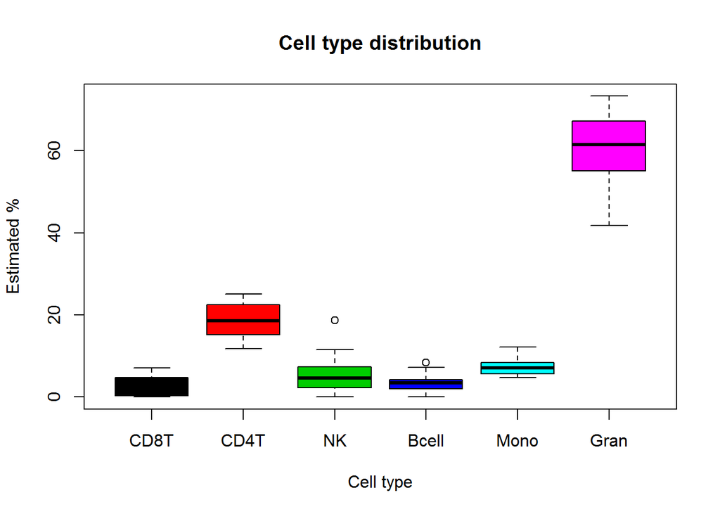

```r
boxplot(cellprop*100, col=1:ncol(cellprop),xlab="Cell type",ylab="Estimated %",main="Cell type distribution")
```

Distribution of estimated cell types by smoking status

```r
meltData <- melt(cbind(as.data.frame(cellprop*100),pData(WB)$SMOKE_STATUS))
```

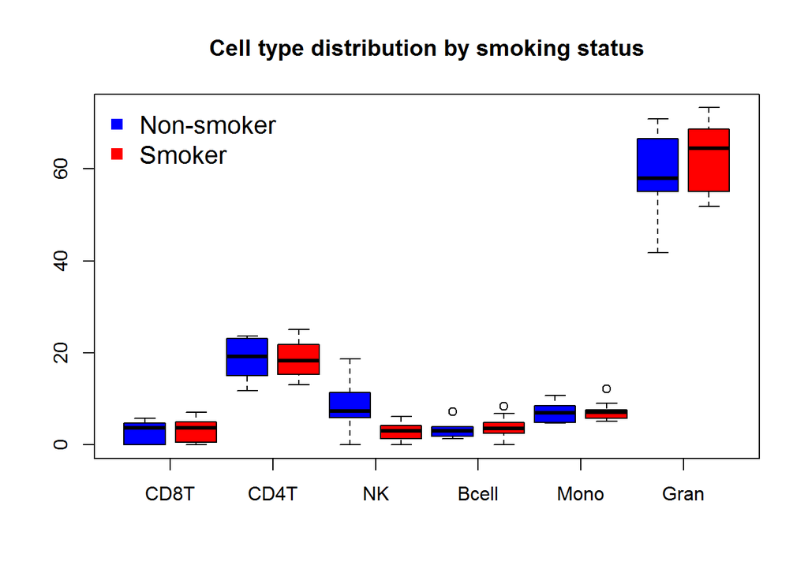

```r
names(meltData)[1:3]<-c('Smoking','Celltype','Proportion')
boxplot(as.numeric(as.character(Proportion)) ~Smoking+Celltype, data=meltData,col=c("blue","red"),xaxt="n",main="Cell type distribution by smoking status")
axis(1,at=seq(from=1.5, to=11.5,by=2),adj=1,labels=c(colnames(cellprop)))
legend("topleft",c("Non-smoker","Smoker"),pch=15,bty='n',col=c("blue","red"),cex=1.3)
```

## Preprocessing the data

Preprocess the data - this removes technical variation  
There are several popular methods including intra- and inter-sample normalizations  
Here we demonstrate an effective and lightweight approach:  
“Normal out of band background” (Noob) within-sample correction - see [Triche et al 2013](http://www.ncbi.nlm.nih.gov/pmc/articles/PMC3627582/)

```r
system.time(WB.noob <- preprocessNoob(WB))
```

```
## [dyeCorrection] Applying R/G ratio flip to fix dye bias
```

```
##    user  system elapsed
##   52.59    7.47   60.15
```

We see the resulting object is now a MethylSet (because the RGset has been preprocessed)

```r
WB.noob
```

```
## class: MethylSet
## dim: 866836 20
## metadata(0):
## assays(2): Meth Unmeth
## rownames(866836): cg18478105 cg09835024 ... cg10633746 cg12623625
## rowData names(0):
## colnames(20): 200383290092_R01C01 200379150024_R04C01 ...
##   200383290066_R04C01 200383290066_R05C01
## colData names(9): ID RACE ... Basename filenames
## Annotation
##   array: IlluminaHumanMethylationEPIC
##   annotation: ilm10b2.hg19
## Preprocessing
##   Method: NA
##   minfi version: NA
##   Manifest version: NA
```

we can look at a few methylation values on the fly and see that the preprocessing changed them:

```r
# first three CpGs on the first three samples
# raw RGset
print(minfi::getBeta(WB)[1:3,1:3], digits = 2)
```

```
##            200383290092_R01C01 200379150024_R04C01 200379150024_R05C01
## cg18478105               0.043               0.030               0.039
## cg09835024               0.064               0.054               0.063
## cg14361672               0.856               0.896               0.850
```

```r
# after preprocessing
print(getBeta(WB.noob)[1:3,1:3], digits = 2)
```

```
##            200383290092_R01C01 200379150024_R04C01 200379150024_R05C01
## cg18478105               0.016               0.011               0.014
## cg09835024               0.034               0.030               0.033
## cg14361672               0.898               0.937               0.891
```

and we can check that the dimensions of the beta matrices are unchanged

```r
identical(dim(minfi::getBeta(WB)), dim(getBeta(WB.noob)))
```

```
## [1] TRUE
```

Distribution of beta-values: before and after normalization

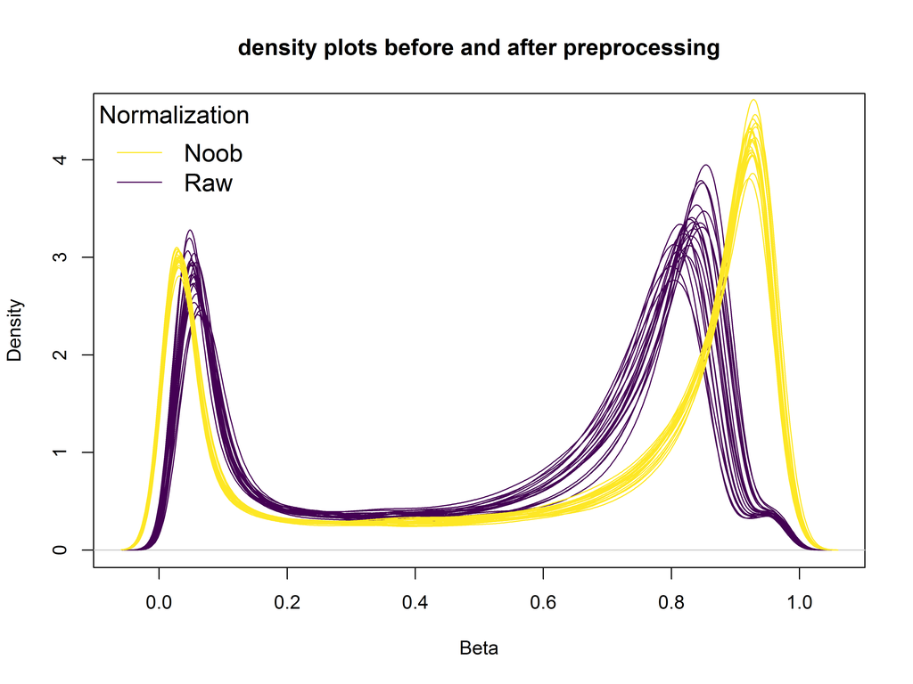

```r
densityPlot(WB, main = "density plots before and after preprocessing", pal="#440154FF", ylim=c(0,4.5))
densityPlot(WB.noob, add = F, pal = "#FDE725FF")
# Add legend
legend("topleft", c("Noob","Raw"),
       lty=c(1,1), title="Normalization",
       bty='n', cex=1.3, col=c("#FDE725FF","#440154FF"))
```

```r
print(colRanges(minfi::getBeta(WB), na.rm = T), digits = 2)
```

```
##         [,1] [,2]
##  [1,] 0.0091 1.00
##  [2,] 0.0000 0.99
##  [3,] 0.0073 1.00
##  [4,] 0.0000 0.99
##  [5,] 0.0118 0.99
##  [6,] 0.0000 1.00
##  [7,] 0.0077 0.99
##  [8,] 0.0093 0.99
##  [9,] 0.0083 1.00
## [10,] 0.0000 0.99
## [11,] 0.0000 1.00
## [12,] 0.0000 1.00
## [13,] 0.0000 0.99
## [14,] 0.0000 0.99
## [15,] 0.0091 1.00
## [16,] 0.0121 1.00
## [17,] 0.0069 0.99
## [18,] 0.0000 1.00
## [19,] 0.0098 0.99
## [20,] 0.0126 0.99
```

```r
print(colRanges(getBeta(WB.noob)), digits = 2)
```

```
##         [,1] [,2]
##  [1,] 0.0075 0.99
##  [2,] 0.0058 0.99
##  [3,] 0.0055 0.99
##  [4,] 0.0056 0.99
##  [5,] 0.0080 0.99
##  [6,] 0.0077 0.99
##  [7,] 0.0071 0.99
##  [8,] 0.0076 0.99
##  [9,] 0.0077 0.99
## [10,] 0.0075 0.99
## [11,] 0.0073 0.99
## [12,] 0.0069 0.99
## [13,] 0.0070 0.99
## [14,] 0.0071 0.99
## [15,] 0.0057 0.99
## [16,] 0.0074 0.99
## [17,] 0.0064 0.99
## [18,] 0.0059 0.99
## [19,] 0.0064 0.99
## [20,] 0.0073 0.99
```

we confirm that plot tails were an artifact of applying a continuous distribution  
(in estimating the density function)

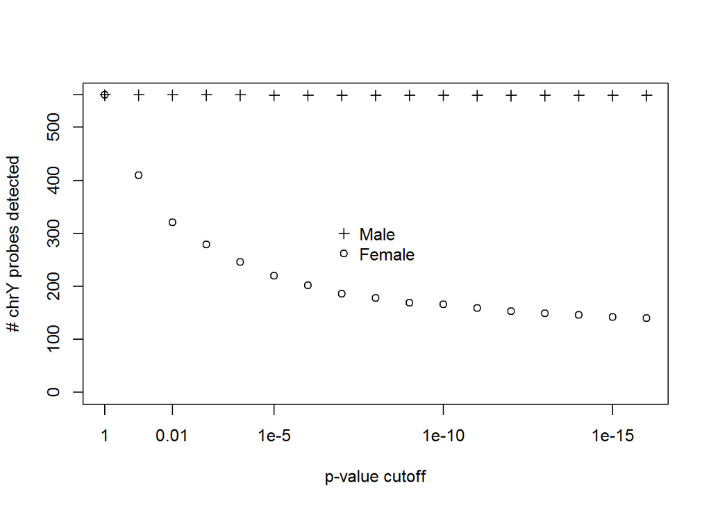

```r
detectionP.minfi <- function(rgSet) {
    minfi:::.isRGOrStop(rgSet)
    locusNames <- getManifestInfo(rgSet, "locusNames")
    detP <- matrix(NA_real_, ncol = ncol(rgSet), nrow = length(locusNames),
                   dimnames = list(locusNames, colnames(rgSet)))

    r <- minfi::getRed(rgSet)
    g <- minfi::getGreen(rgSet)

    controlIdx <- minfi::getControlAddress(rgSet, controlType = "NEGATIVE")

    rBg <- r[controlIdx,,drop=FALSE]
    rMu <- matrixStats::colMedians(rBg)
    rSd <- matrixStats::colMads(rBg)

    gBg <- g[controlIdx,,drop=FALSE]
    gMu <- matrixStats::colMedians(gBg)
    gSd <- matrixStats::colMads(gBg)

    TypeII <- minfi::getProbeInfo(rgSet, type = "II")
    TypeI.Red <- minfi::getProbeInfo(rgSet, type = "I-Red")
    TypeI.Green <- minfi::getProbeInfo(rgSet, type = "I-Green")

    for (i in 1:ncol(rgSet)) {
        ## Type I Red
        intensity <- r[TypeI.Red$AddressA, i] + r[TypeI.Red$AddressB, i]
        detP[TypeI.Red$Name, i] <- pnorm(intensity, mean=rMu[i]*2, sd=rSd[i]*sqrt(2),log.p=TRUE,lower.tail=FALSE)
        ## Type I Green
        intensity <- g[TypeI.Green$AddressA, i] + g[TypeI.Green$AddressB, i]
        detP[TypeI.Green$Name, i] <- pnorm(intensity, mean=gMu[i]*2, sd=gSd[i]*sqrt(2),log.p=TRUE,lower.tail=FALSE)
        ## Type II
        intensity <- r[TypeII$AddressA, i] + g[TypeII$AddressA, i]
        detP[TypeII$Name, i] <- pnorm(intensity, mean=rMu[i]+gMu[i], sd=sqrt(rSd[i]^2+gSd[i]^2),log.p=TRUE,lower.tail=FALSE)
    }

  detP/log(10)
}

detP = detectionP.minfi(WB)
chrY = which(getAnnotation(WB)@listData$chr == "chrY")
detP = detP[chrY,]
sexes = split(1:20,pData(WB)$SEX)
cutoffs = -(0:16)

tmp = sapply(cutoffs,function(t){ colSums(detP<t,na.rm=TRUE) })
sexes$male   = apply(tmp[sexes$male  ,],2,median)
sexes$female = apply(tmp[sexes$female,],2,median)

plot  (-cutoffs,sexes$female,ylim=c(0,nrow(detP)),ylab="# chrY probes detected",xlab="p-value cutoff",xaxt="n",yaxt="n")
points(-cutoffs,sexes$male,pch=3)
axis(1,at=c(0,2,5,10,15),labels=c("1","0.01","1e-5","1e-10","1e-15"))
axis(2,at=c(0,100,200,300,400,500,561),labels=c(0,100,200,300,400,500,561))
legend("center",pch=c(3,1),legend=c('Male','Female'),bty="n")
```

## probe failures due to low intensities

We want to drop probes with intensity that is not significantly above background signal (from negative control probes)

```r
detect.p <- minfi::detectionP(WB, type = "m+u")
```

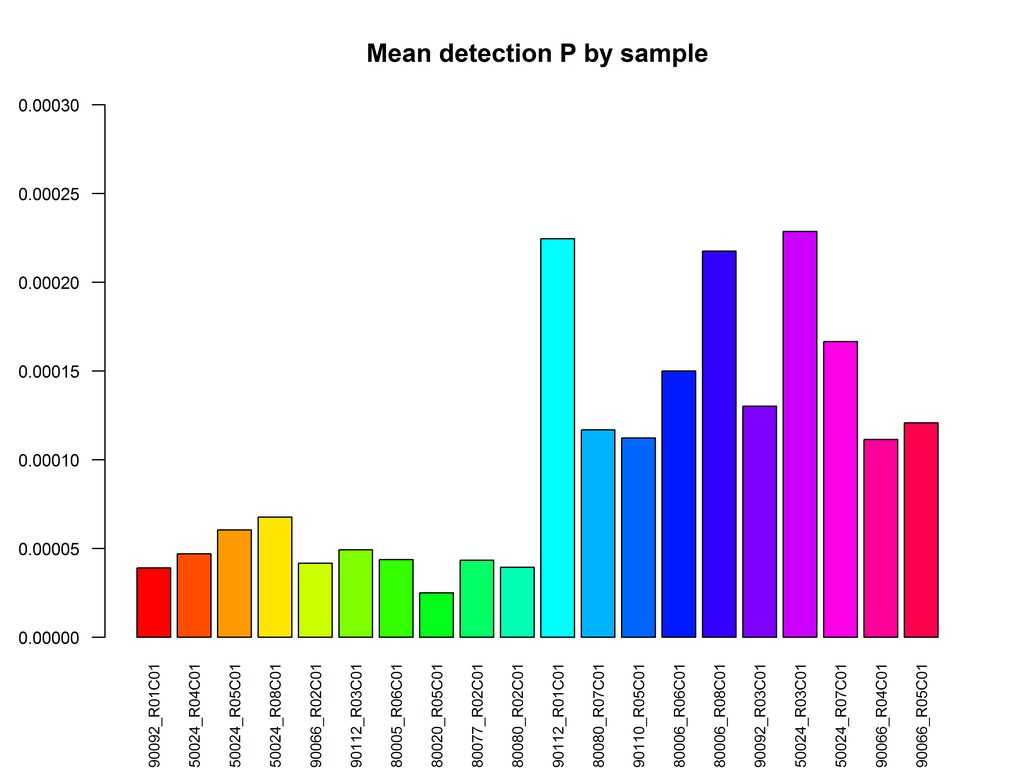

```r
barplot(colMeans(detect.p), col=rainbow(dim(detect.p)[2]), las=2,
        cex.names=0.7, main="Mean detection P by sample",cex.axis=0.8, ylim=c(0,3e-4))
```

Count of failed probes per sample P>0.01 (i.e. not significant compared to background signal)

```r
knitr::kable(t(as.matrix(colSums(detect.p > 0.01))[1:5,]))
```

| 200383290092_R01C01 | 200379150024_R04C01 | 200379150024_R05C01 | 200379150024_R08C01 | 200383290066_R02C01 |
| --- | --- | --- | --- | --- |
| 159 | 235 | 264 | 321 | 199 |

```r
knitr::kable(t(as.matrix(colSums(detect.p > 0.01))[6:10,]))
```

| 200383290112_R03C01 | 200383880005_R06C01 | 200383880020_R05C01 | 200383880077_R02C01 | 200383880080_R02C01 |
| --- | --- | --- | --- | --- |
| 216 | 187 | 138 | 198 | 181 |

```r
knitr::kable(t(as.matrix(colSums(detect.p > 0.01))[11:15,]))
```

| 200383290112_R01C01 | 200383880080_R07C01 | 200383290110_R05C01 | 200383880006_R06C01 | 200383880006_R08C01 |
| --- | --- | --- | --- | --- |
| 596 | 425 | 416 | 543 | 588 |

```r
knitr::kable(t(as.matrix(colSums(detect.p > 0.01))[16:20,]))
```

| 200383290092_R03C01 | 200379150024_R03C01 | 200379150024_R07C01 | 200383290066_R04C01 | 200383290066_R05C01 |
| --- | --- | --- | --- | --- |
| 450 | 721 | 534 | 421 | 456 |

This is less than 1% of probes per sample  
Total number of failed measures (in all probes)

```r
sum(detect.p > 0.01)
```

```
## [1] 7248
```

Restrict data to good probes only:

```r
detect.p[detect.p > 0.01] <- NA
detect.p <- na.omit(detect.p)
intersect <- intersect(rownames(getAnnotation(WB)), rownames(detect.p))
length(intersect)
```

```
## [1] 864678
```

Filter bad probes from our methylset

```r
nrow(WB.noob)
```

```
## [1] 866836
```

```r
WB.noob <- WB.noob[rownames(getAnnotation(WB.noob)) %in% intersect,]
nrow(WB.noob)
```

```
## [1] 864678
```

```r
# cleanup
rm(intersect, detect.p);gc()
```

```
##             used   (Mb) gc trigger   (Mb)  max used   (Mb)
## Ncells  16210623  865.8   35329607 1886.9  23700528 1265.8
## Vcells 293220993 2237.1  801667516 6116.3 801643985 6116.1
```

# Probe type adjustment

Need to adjust for probe-type bias Infinium I (type I) and Infinium II (type II) probes  
RCP with EnMix: Regression on Correlated Probes [Niu et al. Bioinformatics 2016](http://www.ncbi.nlm.nih.gov/pubmed/27153672)

```r
betas.rcp <- rcp(WB.noob)
dim(betas.rcp)
```

```
## [1] 864678     20
```

note that this package takes beta values out of the minfi object - result is a matrix

```r
class(betas.rcp)
```

```
## [1] "matrix"
```

```r
## Annotation of Infinium type for each probe (I vs II)
typeI <-   minfi::getProbeInfo(WB.noob,type="I")$Name
typeII <-  minfi::getProbeInfo(WB.noob,type="II")$Name
onetwo <- rep(1, nrow(betas.rcp))
onetwo[rownames(betas.rcp) %in% typeII] <- 2
# almost 84% of our probes are type II
knitr::kable(t(table(onetwo)))
```

| 1 | 2 |
| --- | --- |
| 142013 | 722665 |

Density plots by Infinium type: before and after RCP calibration  
Probe-type bias adjustment before and after RCP

```r
par(mfrow=c(1,2)) # Side-by-side density distributions
densityPlot(WB.noob[rownames(getAnnotation(WB.noob)) %in% typeI,],pal = "#FDE725FF",main='Beta density',ylim=c(0,6.5))
densityPlot(WB.noob[rownames(getAnnotation(WB.noob)) %in% typeII,],add = F, pal = "#440154FF")
densityPlot(betas.rcp[rownames(getAnnotation(WB.noob)) %in% typeI,],pal = "#FDE725FF",main='Beta density probe-type adjusted',ylim=c(0,6.5))
densityPlot(betas.rcp[rownames(getAnnotation(WB.noob)) %in% typeII,],add = F, pal = "#440154FF")
legend("center", c("Infinium I","Infinium II"),
       lty=c(1,1), title="Infinium type",
       bty='n',col=c("#FDE725FF","#440154FF"))
```

[figure not shown]

notice that the type I and II peaks are more closely aligned after rcp adjustment  
(particularly in the higher peak)

```r
rm(onetwo, typeI, typeII)
```

## Batch effects

As an example of an observable batch effect, samples are processed in plates (e.g. bisulfite converting 96 at a time),  
and then in chips (EPIC array has 8 rows and 1 column).  
This can create batch effects (technical variation) with different intensities by position (row effect).  
Other commonly observed batch effects include bisulfite processing plate, chip, and processing date. Let’s check if samples varied across rows in these data (even in different chips):

```r
pData(WB.noob)$Array <- pData(WB.noob)$Sentrix_Position
knitr::kable(t(as.matrix(table(pData(WB.noob)$Array))),
             col.names = paste0("Row ", 1:8))
```

| Row 1 | Row 2 | Row 3 | Row 4 | Row 5 | Row 6 | Row 7 | Row 8 |
| --- | --- | --- | --- | --- | --- | --- | --- |
| 2 | 3 | 3 | 2 | 4 | 2 | 2 | 2 |

## Principal Component Analysis (PCA)

Calculate major sources of variability of DNA methylation using PCA

```r
PCobject = prcomp(t(betas.rcp), retx = T, center = T, scale. = T)
```

Extract the Principal Components from SVD

```r
PCs <- PCobject$x
```

Proportion of variance explained by each additional PC

```r
cummvar <- summary(PCobject)$importance["Cumulative Proportion", 1:10]
knitr::kable(t(as.matrix(cummvar)),digits = 2)
```

| PC1 | PC2 | PC3 | PC4 | PC5 | PC6 | PC7 | PC8 | PC9 | PC10 |
| --- | --- | --- | --- | --- | --- | --- | --- | --- | --- |
| 0.16 | 0.28 | 0.37 | 0.43 | 0.49 | 0.54 | 0.59 | 0.64 | 0.68 | 0.72 |

Is the major source of variability associated with position on chip?

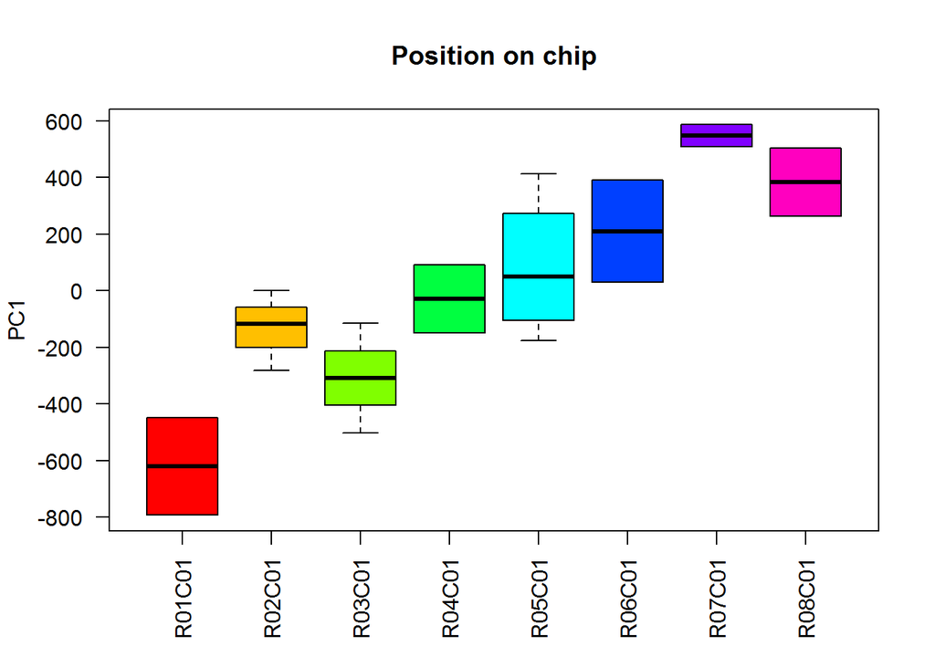

```r
par(mfrow = c(1, 1))
boxplot(PCs[, 1] ~ pData(WB.noob)$Array,
        ylab = "PC1",las=2, main="Position on chip",col=rainbow(8))
```

```r
summary(lm(PCs[, 1] ~ pData(WB.noob)$Array))
```

```
##
## Call:
## lm(formula = PCs[, 1] ~ pData(WB.noob)$Array)
##
## Residuals:
##     Min      1Q  Median      3Q     Max
## -260.10 -127.82    7.78  123.98  328.47
##
## Coefficients:
##                            Estimate Std. Error t value Pr(>|t|)
## (Intercept)                  -619.9      143.2  -4.329 0.000981 ***
## pData(WB.noob)$ArrayR02C01    487.5      184.9   2.637 0.021708 *
## pData(WB.noob)$ArrayR03C01    311.6      184.9   1.685 0.117738
## pData(WB.noob)$ArrayR04C01    590.8      202.5   2.917 0.012905 *
## pData(WB.noob)$ArrayR05C01    703.8      175.4   4.013 0.001722 **
## pData(WB.noob)$ArrayR06C01    830.2      202.5   4.099 0.001475 **
## pData(WB.noob)$ArrayR07C01   1167.9      202.5   5.767 8.92e-05 ***
## pData(WB.noob)$ArrayR08C01   1003.9      202.5   4.957 0.000332 ***
## ---
## Signif. codes:  0 '***' 0.001 '**' 0.01 '*' 0.05 '.' 0.1 ' ' 1
##
## Residual standard error: 202.5 on 12 degrees of freedom
## Multiple R-squared:  0.8116, Adjusted R-squared:  0.7017
## F-statistic: 7.385 on 7 and 12 DF,  p-value: 0.001438
```

## Removing batch effects using ComBat from the sva package

```r
# First we convert from beta-values to M-values
Mvals <- log2(betas.rcp)-log2(1-betas.rcp)
```

ComBat eBayes adjustment using a known variable of interest (here we use row)

```r
Mvals.ComBat <- ComBat(Mvals, batch = pData(WB.noob)$Array)
```

```
## Found8batches
```

```
## Adjusting for0covariate(s) or covariate level(s)
```

```
## Standardizing Data across genes
```

```
## Fitting L/S model and finding priors
```

```
## Finding parametric adjustments
```

```
## Adjusting the Data
```

```r
# Convert M-values back to beta-values
betas.rcp <- 2^Mvals.ComBat/(1+2^Mvals.ComBat)
```

PCA after removing batch effects

```r
PCobject <- prcomp(t(betas.rcp), retx = T, center = T, scale. = T)
PCs <- PCobject$x
```

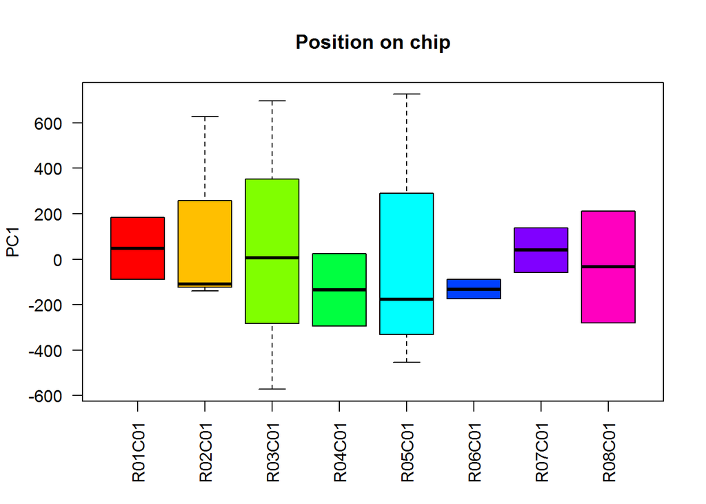

```r
boxplot(PCs[, 1] ~ pData(WB.noob)$Array,
        ylab = "PC1",las=2, main="Position on chip",col=rainbow(8))
```

```r
summary(lm(PCs[, 1] ~ pData(WB.noob)$Array))
```

```
##
## Call:
## lm(formula = PCs[, 1] ~ pData(WB.noob)$Array)
##
## Residuals:
##     Min      1Q  Median      3Q     Max
## -615.47 -199.03  -71.07  142.63  746.53
##
## Coefficients:
##                            Estimate Std. Error t value Pr(>|t|)
## (Intercept)                  47.906    303.527   0.158    0.877
## pData(WB.noob)$ArrayR02C01   78.168    391.852   0.199    0.845
## pData(WB.noob)$ArrayR03C01   -4.299    391.852  -0.011    0.991
## pData(WB.noob)$ArrayR04C01 -182.799    429.252  -0.426    0.678
## pData(WB.noob)$ArrayR05C01  -68.755    371.743  -0.185    0.856
## pData(WB.noob)$ArrayR06C01 -179.371    429.252  -0.418    0.683
## pData(WB.noob)$ArrayR07C01   -8.232    429.252  -0.019    0.985
## pData(WB.noob)$ArrayR08C01  -81.947    429.252  -0.191    0.852
##
## Residual standard error: 429.3 on 12 degrees of freedom
## Multiple R-squared:  0.058,  Adjusted R-squared:  -0.4915
## F-statistic: 0.1056 on 7 and 12 DF,  p-value: 0.9968
```

ComBat removed the apparent batch effect

```r
#cleanup
rm(PCs, Mvals, cummvar, PCobject)
```

Phenotype associated with large sources of variability

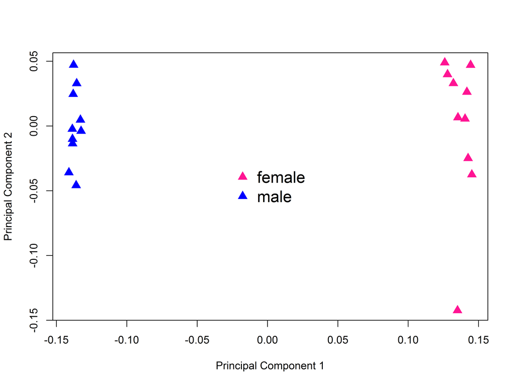

```r
plotMDS(getBeta(WB.noob), top=10000, gene.selection="common",
        pch=17,col=c("deeppink","blue")[factor(pData(WB.noob)$SEX)],
        dim=c(1,2),cex=1.5)
legend("center", legend=levels(factor(pData(WB.noob)$SEX)),bty='n',
       cex=1.5,pch=17,col=c("deeppink","blue"))
```

## predict sex from methylation

```r
Gbeta <- mapToGenome(WB)  #map to the genome
```

getSex predicts sex based on X and Y chromosome methylation intensity

```r
getSex(Gbeta)
```

```
## DataFrame with 20 rows and 3 columns
##                                 xMed             yMed predictedSex
##                            <numeric>        <numeric>  <character>
## 200383290092_R01C01 12.3963371942311 12.5693809595223            M
## 200379150024_R04C01 12.6111400930033  12.815583433851            M
## 200379150024_R05C01 12.6624458575807 12.8637991037288            M
## 200379150024_R08C01 12.4721831161895 12.6434052771157            M
## 200383290066_R02C01 12.4690057868245 12.5999128421871            M
## ...                              ...              ...          ...
## 200383290092_R03C01 13.1848753429083 9.38154295118458            F
## 200379150024_R03C01 13.1103201736097 9.24079133216196            F
## 200379150024_R07C01 13.2892984719035 9.37721053038855            F
## 200383290066_R04C01 13.0765651050006 9.34651373316563            F
## 200383290066_R05C01 13.1454545640095 9.44501484586842            F
```

we see that our predictions match the phenodata

```r
table(pData(WB)$SEX,getSex(Gbeta)$predictedSex)
```

```
##
##           F  M
##   female 10  0
##   male    0 10
```

We can actually look at the intensities in the sex-crhomosomes

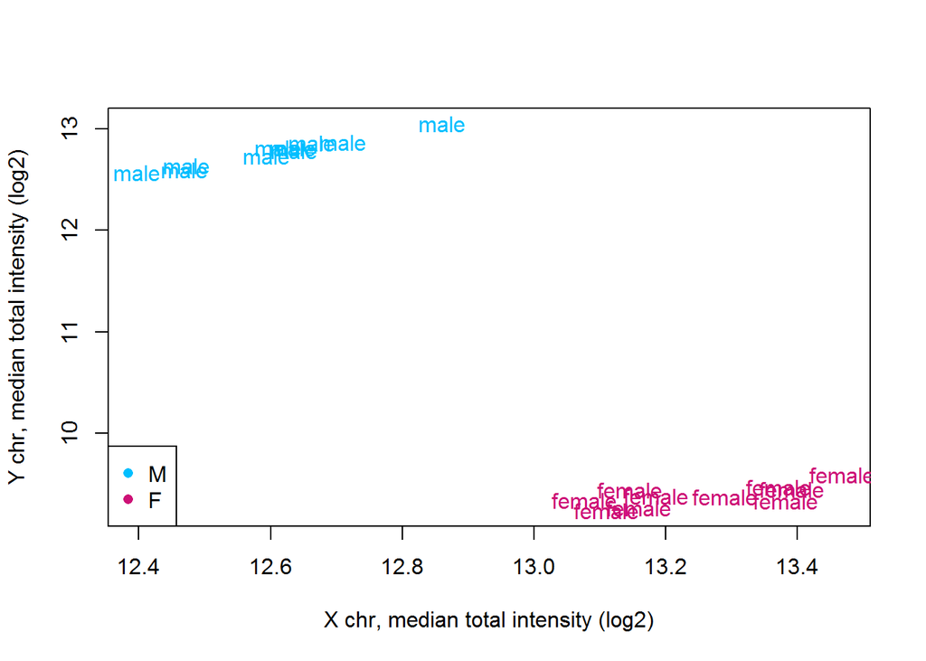

```r
Gbeta = addSex(Gbeta)
plotSex(Gbeta,id=pData(WB)$SEX)
```

```r
# cleanup

save(WB,WB.noob,file="C:/EBC3/Data/WB.noob.RData")
save(betas.rcp,file="C:/EBC3/Data/betas.rcp.RData")
save(Gbeta,file="C:/EBC3/Data/Gbeta.RData")
```

# memory usage

as a reminder - these are large datasets and we are working in RAM.  
Check memory usage with:

```r
pryr::mem_used()
```

```
## 3.69 GB
```

```r
# this command will check the maximum memory usage on Windows
memory.size(max = T)
```

```
## [1] 8379.56
```

End of script 1